# Understanding UART Data Output Format

## Understanding the UART Data Output Format

To understand the data output from the EVM, it is important to understand how the device itself works. The mmWave radar sensor is a Frequency-Modulated Continuous Wave (FMCW) radar sensor that is able to detect the range, velocity, and angle of objects. To operate this device, configurations determining the properties of the chirps transmitted from the radar are sent via configuration commands/files in a Command Line Interface (CLI) to the device via UART.

When the chirp returns after bouncing off an object, it is mixed with the original transmit chirp to determine range, velocity, and angle. The resulting signal is digitized and organized into a Type Length Value structure (TLV) based on the demo being run. This information is then packed into an output structure and sent back to the computer via UART. The current UART output is sent out every frame as a packet containing a frame header and TLV.

Each TLV item in the packet payload contains a data type and value (payload) containing information describing that type of information. The length of the packet can depend on the number of detected objects and vary from frame to frame. To maintain uniformity amongst packets, each packet is padded so that the length is a multiple of 32 bytes. The UART information is sent out from the EVM board to the USB port of the computer and then parsed to process and display the results onto a GUI visualizer.

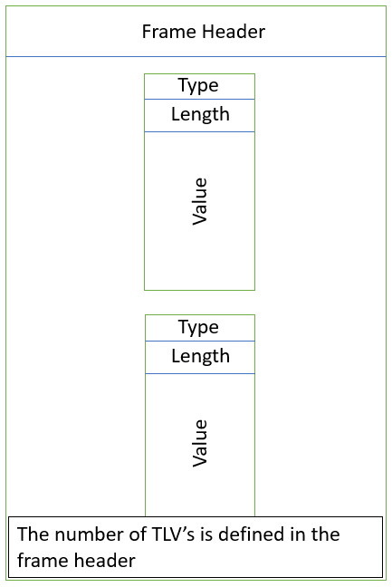

> 📝 **NOTE:**  
> For more information on xWRLx432 TLVs and output data (SDK 5.x) refer to section 13 of the implementation guide located at /docs/MotionPresenceDetectionDemo_documentation.pdf.

## Frame Header

Length: 40 Bytes  
A Frame Header is sent at the start of each packet. Use the Magic Word to find the start of each packet. The frame header is setup differently than the output TLVs. The frame header is setup to be rigid as it will always come first and always be in the same format, as a result it is based off of its own struct named MmwDemo_output_message_header with defined struct members.

| Value | Type | Bytes | Details |
| --- | --- | --- | --- |
| Magic Word | uint16_t | 8 | Output buffer magic word (sync word). It is initialized to {0x0102,0x0304,0x0506,0x0708} |
| Version | uint32_t | 4 | SDK Version represented as (MajorNum x 2^24 + MinorNum x 2^16 + BugfixNum x 2^8 + BuildNum) |
| Total Packet Length | uint32_t | 4 | Total packet length including frame header length in Bytes |
| Platform | uint32_t | 4 | Device type (ex 0xA6843 for IWR6843 devices) |
| Frame Number | uint32_t | 4 | Frame number (resets to 0 when device is power cycled or reset. Not when sensor stop/start is issued.) |
| Time [in CPU Cycles] | uint32_t | 4 | Time in CPU cycles when the message was created. |
| Num Detected Obj | uint32_t | 4 | Number of detected objects (points) for the frame |
| Num TLVs | uint32_t | 4 | Number of TLV items for the frame. |
| Subframe Number | uint32_t | 4 | 0 if advanced subframe mode not enabled, otherwise the sub-frame number in the range 0 to (number of subframes - 1) |

## TLV Header

Length: 8 Bytes  
The number of TLVs in the frame packet is extracted from the Frame Header. For each TLV in the packet, there is a TLV Header containing Type and Length information. The Type identifier indicates what kind of information is contained in the payload. The Length value gives the length of the payload.

| Value | Type | Bytes | Details |
| --- | --- | --- | --- |
| Type | uint32_t | 4 | Indicates types of message contained in payload. |
| Length | uint32_t | 4 | Length of the payload in Bytes (does not include length of the TLV header) |

## TLV Toggling with guiMonitor

The parameters in the CLI command **guiMonitor** are used to enable or disable whether the TLV type is included in the output frame packet. The parameters are as follows: `guiMonitor <subFrameIdx> <detected objects> <log magnitude range> <noise profile> <rangeAzimuth(Elevation)HeatMap> <rangeDopplerHeatMap> <statsInfo>`

For the Out of Box demo, if type contains the following value then the payload contains the information listed under value type and should be parsed accordingly.

| Type Identifier | Value Type | Condition for output |
| --- | --- | --- |
| 1 | Detected Points | `<detected objects>` is set to 1 or 2 AND there are detected objects for the frame, else this type is not sent for that frame |
| 2 | Range Profile | `<log magnitude range>` is set to 1; occurs every frame |
| 3 | Noise Floor Profile | `<noise profile>` is set to 1; occurs every frame |
| 4 | Azimuth Static Heatmap | `<rangeAzimuth(Elevation)HeatMap>` is set to 1 AND demo is not for AOP or ODS which use AOA2D; occurs every frame |
| 5 | Range-Doppler Heatmap | `<rangeDopplerHeatMap>` is set to 1; occurs every frame |
| 6 | Statistics (Performance) | `<statsInfo>` is set to 1; occurs every frame |
| 7 | Side Info for Detected Points | `<detected objects>` is set to 2 AND there are detected objects for the frame, else this type is not sent for that frame |
| 8 | Azimuth/Elevation Static Heatmap | `<rangeAzimuth(Elevation)HeatMap>` is set to 1 AND demo is for AOP or ODS which use AOA2D; occurs every frame |
| 9 | Temperature Statistics | `<statsInfo>` is set to 1; occurs every frame |

## Availability of Universal TLV’s in Labs

The list below covers TLVs that can be found across all mmWave radar example demos. Clicking on a type name will take you to the appropriate section. Note that TLVs with similar functions will have different type identifer based off of the source. Some demos will have TLVs only from one of the SDKs and others will have TLVs from both the SDK and Radar Toolbox.

| Type Identifier | Type Name | Source |
| --- | --- | --- |
| 1 | `MMWDEMO_OUTPUT_MSG_DETECTED_POINTS` | MMWAVE-SDK MMWAVE-L-SDK-6 |
| 2 | `MMWDEMO_OUTPUT_MSG_RANGE_PROFILE` | MMWAVE-SDK MMWAVE-L-SDK-6 |
| 3 | `MMWDEMO_OUTPUT_MSG_NOISE_PROFILE` | MMWAVE-SDK |
| 4 | `MMWDEMO_OUTPUT_MSG_AZIMUT_STATIC_HEAT_MAP` | MMWAVE-SDK |
| 5 | `MMWDEMO_OUTPUT_MSG_RANGE_DOPPLER_HEAT_MAP` | MMWAVE-SDK MMWAVE-L-SDK-6 |
| 6 | `MMWDEMO_OUTPUT_MSG_STATS` | MMWAVE-SDK MMWAVE-L-SDK-6 |
| 7 | `MMWDEMO_OUTPUT_MSG_DETECTED_POINTS_SIDE_INFO` | MMWAVE-SDK MMWAVE-L-SDK-5 MMWAVE-L-SDK-6 |
| 8 | `MMWDEMO_OUTPUT_MSG_AZIMUT_ELEVATION_STATIC_HEAT_MAP` | MMWAVE-SDK |
| 9 | `MMWDEMO_OUTPUT_MSG_TEMPERATURE_STATS` | MMWAVE-SDK |
| 301 | `MMWDEMO_OUTPUT_EXT_MSG_DETECTED_POINTS` | MMWAVE-L-SDK-5 |
| 302 | `MMWDEMO_OUTPUT_EXT_MSG_RANGE_PROFILE_MAJOR` | MMWAVE-L-SDK-5 |
| 303 | `MMWDEMO_OUTPUT_EXT_MSG_RANGE_PROFILE_MINOR` | MMWAVE-L-SDK-5 |
| 304 | `MMWDEMO_OUTPUT_EXT_MSG_RANGE_AZIMUT_HEAT_MAP_MAJOR` | MMWAVE-L-SDK-5 |
| 305 | `MMWDEMO_OUTPUT_EXT_MSG_RANGE_AZIMUT_HEAT_MAP_MINOR` | MMWAVE-L-SDK-5 |
| 306 | `MMWDEMO_OUTPUT_EXT_MSG_STATS` | MMWAVE-L-SDK-5 |
| 308 | `MMWDEMO_OUTPUT_EXT_MSG_TARGET_LIST` | MMWAVE-L-SDK-5 |
| 309 | `MMWDEMO_OUTPUT_EXT_MSG_TARGET_INDEX` | MMWAVE-L-SDK-5 |
| 310 | `MMWDEMO_OUTPUT_EXT_MSG_MICRO_DOPPLER_RAW_DATA` | MMWAVE-L-SDK-5 |
| 311 | `MMWDEMO_OUTPUT_EXT_MSG_MICRO_DOPPLER_FEATURES` | MMWAVE-L-SDK-5 |
| 312 | `MMWDEMO_OUTPUT_EXT_MSG_RADAR_CUBE_MAJOR` | MMWAVE-L-SDK-5 |
| 313 | `MMWDEMO_OUTPUT_EXT_MSG_RADAR_CUBE_MINOR` | MMWAVE-L-SDK-5 |
| 315 | `MMWDEMO_OUTPUT_EXT_MSG_ENHANCED_PRESENCE_INDICATION` | MMWAVE-L-SDK-5 |
| 316 | `MMWDEMO_OUTPUT_EXT_MSG_ADC_SAMPLES` | MMWAVE-L-SDK-5 |
| 317 | `MMWDEMO_OUTPUT_EXT_MSG_CLASSIFIER_INFO` | MMWAVE-L-SDK-5 |
| 318 | `MMWDEMO_OUTPUT_EXT_MSG_RX_CHAN_COMPENSATION_INFO` | MMWAVE-L-SDK-5 MMWAVE-L-SDK-6 |
| 319 | `MMWDEMO_OUTPUT_EXT_MSG_QUICK_EVAL_INFO` | MMWAVE-L-SDK-5 |
| 320 | `MMWDEMO_OUTPUT_EXT_MSG_POINT_CLOUD_ANTENNA_SYMBOLS` | MMWAVE-L-SDK-5 |
| 1000 | `MMWDEMO_OUTPUT_MSG_SPHERICAL_POINTS` | Radar Toolbox |
| 1010 | `MMWDEMO_OUTPUT_MSG_TRACKERPROC_3D_TARGET_LIST` | Radar Toolbox |
| 1011 | `MMWDEMO_OUTPUT_MSG_TRACKERPROC_TARGET_INDEX` | Radar Toolbox |
| 1012 | `MMWDEMO_OUTPUT_MSG_TRACKERPROC_TARGET_HEIGHT` | Radar Toolbox |
| 1020 | `MMWDEMO_OUTPUT_MSG_COMPRESSED_POINTS` | Radar Toolbox |
| 1021 | `MMWDEMO_OUTPUT_MSG_PRESCENCE_INDICATION` | Radar Toolbox |
| 1030 | `MMWDEMO_OUTPUT_MSG_OCCUPANCY_STATE_MACHINE` | Radar Toolbox |
| 1031 | `MMWDEMO_OUTPUT_MSG_SURFACE_CLASSIFICATION_PROBABILITY` | Radar Toolbox |
| 1034 | `MMWDEMO_OUTPUT_EXT_MSG_STATS_BSD` | Radar Toolbox |
| 1035 | `MMWDEMO_OUTPUT_EXT_MSG_TARGET_LIST_2D_BSD` | Radar Toolbox |
| 1040 | `MMWDEMO_OUTPUT_MSG_VITALSIGNS` | Radar Toolbox |
| 1050 | `MMWDEMO_OUTPUT_MSG_GESTURE_FEATURES` | Radar Toolbox |
| 1051 | `MMWDEMO_OUTPUT_MSG_ANN_OP_PROB` | Radar Toolbox |
| 1060 | `MMWDEMO_OUTPUT_EXT_MSG_MODE_SWITCH_INFO` | Radar Toolbox |
| 1061 | `MMWDEMO_OUTPUT_EXT_MSG_CAMERA_ON_IND` | Radar Toolbox |
| 1062 | `MMWDEMO_OUTPUT_EXT_MSG_CLUSTER_LOCATIONS` | Radar Toolbox |
| 3000 | `MMWDEMO_OUTPUT_EXT_MSG_CAM_TRIGGERS` | Radar Toolbox |

## TLV Payload

### Detected Points

#### xWRL6844, xWR6843, xWR1843, xWR1642, xWR1443

| Type Identifier | Type Value | Length | Value |
| --- | --- | --- | --- |
| 1 | `MMWDEMO_OUTPUT_MSG_DETECTED_POINTS` | (Num Detected Obj) x (16 Bytes) | Array of detected points |

Each point is represented by 16 bytes giving position and radial Doppler velocity as shown in the table below

| Value | Type | Bytes |
| --- | --- | --- |
| X [m] | float | 4 |
| Y [m] | float | 4 |
| Z [m] | float | 4 |
| doppler [m/s] | float | 4 |

For the point cloud format of the xWRL6432 and xWRL1432, see TLV 301:  
`MMWDEMO_OUTPUT_EXT_MSG_DETECTED_POINTS`

### Range Profile

#### xWRL6844, xWR6843, xWR1843, xWR1642, xWR1443

| Type Identifier | Type Value | Length | Value |
| --- | --- | --- | --- |
| 2 | `MMWDEMO_OUTPUT_MSG_RANGE_PROFILE` | (Range FFT size) x (2 Bytes) | Array of profile points at 0th Doppler (stationary objects). The points represent the sum of log2 magnitudes of received antennas expressed in Q9 format. |

#### xWRLx432

##### Range Profile Major

| Type Identifier | Type Value | Length | Value |
| --- | --- | --- | --- |
| 302 | `MMWDEMO_OUTPUT_EXT_MSG_RANGE_PROFILE_MAJOR` | (Number Of Range Bins) x (4 Bytes) | Array of 32-bit unsigned linear values of range bins for major motion. The length is equal to number of range bin elements |

##### Range Profile Minor

[output not shown]

### Noise Profile

[output not shown]

### Azimuth Static Heatmap

| Type Identifier | Type Value | Length | Value |
| --- | --- | --- | --- |
| 4 | `MMWDEMO_OUTPUT_MSG_AZIMUT_STATIC_HEAT_MAP` | (Range FFT size) x (Number of “azimuth” virtual antennas) x (4 Bytes) | Samples to calculate static azimuth heatmap (no moving object signal). This is a 2D FFT array in range direction (x[numRangeBins][numVirtualAntAzim]), at doppler index 0. |

The antenna data are complex symbols, with imaginary first and real second in the following order:

Imag(ant 0, range 0), Real(ant 0, range 0),…,Imag(ant N-1, range 0),Real(ant N-1, range 0)  
…  
Imag(ant 0, range R-1), Real(ant 0, range R-1),…,Imag(ant N-1, range R-1),Real(ant N-1, range R-1)

This means the first 4 bytes of the payload is the radar cube complex value of the first range bin for the first virtual antenna(N=1). The last 4 bytes is for the last range bin (R) and the last virtual antenna (N). The values from the radar cube are used to construct the range-azimuth heatmap in the visualizer.

### Range-Doppler Heatmap

| Type Identifier | Type Value | Length | Value |
| --- | --- | --- | --- |
| 5 | `MMWDEMO_OUTPUT_MSG_RANGE_DOPPLER_HEAT_MAP` | (Range FFT size) x (Doppler FFT size) x (2 Bytes) | Range/Doppler detection matrix. |

X(range bin 0, Doppler bin 0),…,X(range bin 0, Doppler bin D-1),  
…  
X(range bin R-1, Doppler bin 0),…,X(range bin R-1, Doppler bin D-1)

### Statistics

| Type Identifier | Type Value | Length | Value |
| --- | --- | --- | --- |
| 6 | `MMWDEMO_OUTPUT_MSG_STATS` | 24 Bytes | Statistical performance information from data path. |

See the doxygen for detailed explanation of each stat.

| Value | Type | Bytes |
| --- | --- | --- |
| interFrameProcessingTime [usec] | uint32_t | 4 |
| transmitOutputTime[usec] | uint32_t | 4 |
| interFrameProcessingMargin [usec] | uint32_t | 4 |
| interChirpProcessingMargin [usec] | uint32_t | 4 |
| activeFrameCPULoad [%] | uint32_t | 4 |
| interFrameCPULoad [%] | uint32_t | 4 |

### Side Info for Detected Points

| Type Identifier | Type Value | Length | Value |
| --- | --- | --- | --- |
| 7 | `MMWDEMO_OUTPUT_MSG_DETECTED_POINTS_SIDE_INFO` | 4 Bytes x Num Detected Obj | Provides side info which includes the Signal-to-Noise Ratio (SNR) and Noise |

The payload consists of 4 bytes for EACH point in the point cloud. The values for snr and noise are measured in multiples of 0.1dB.

| Value | Type | Bytes |
| --- | --- | --- |
| snr [dB] | uint16_t | 2 |
| noise [dB] | uint16_t | 2 |

### Azimuth/Elevation Static Heatmap

| Type Identifier | Type Value | Length | Value |
| --- | --- | --- | --- |
| 8 | `MMWDEMO_OUTPUT_MSG_AZIMUT_ELEVATION_STATIC_HEAT_MAP` | (Range FFT size) x (Number of all virtual antennas) x (4 Bytes) | Samples to calculate static azimuth or elevation heatmap (no moving object signal). This is a 2D FFT array in range direction (x[numRangeBins][numVirtualAntAzim]), at doppler index 0. |

The antenna data are complex symbols, with imaginary first and real second in the following order:

Imag(ant 0, range 0), Real(ant 0, range 0),…,Imag(ant N-1, range 0),Real(ant N-1, range 0)  
…  
Imag(ant 0, range R-1), Real(ant 0, range R-1),…,Imag(ant N-1, range R-1),Real(ant N-1, range R-1)

> 📝 **NOTE:**  
> The demo will only output either the Azimuth Static Heatmap **OR** the Azimuth/Elevation Static Heatmap

### Temperature Statistics

| Type Identifier | Type Value | Length | Value |
| --- | --- | --- | --- |
| 9 | `MMWDEMO_OUTPUT_MSG_TEMPERATURE_STATS` | 28 Bytes | Temperature report - snapshot taken just before shipping data over UART. |

Table of each temperature reading sent is shown below:

| Value | Type | Bytes |
| --- | --- | --- |
| tempReportValid (used to know if values are valid) | uint32_t | 4 |
| time (radarSS local Time from device powerup) [1LSB = 1ms] | uint32_t | 4 |
| tmpRx0Sens [1 LSB = 1 deg C] | uint16_t | 2 |
| tmpRx1Sens [1 LSB = 1 deg C] | uint16_t | 2 |
| tmpRx2Sens [1 LSB = 1 deg C] | uint16_t | 2 |
| tmpRx3Sens [1 LSB = 1 deg C] | uint16_t | 2 |
| tmpTx0Sens [1 LSB = 1 deg C] | uint16_t | 2 |
| tmpTx1Sens [1 LSB = 1 deg C] | uint16_t | 2 |
| tmpTx2Sens [1 LSB = 1 deg C] | uint16_t | 2 |
| tmpPmSens [1 LSB = 1 deg C] | uint16_t | 2 |
| tmpDig0Sens [1 LSB = 1 deg C] | uint16_t | 2 |
| tmpDig1Sens [1 LSB = 1 deg C] (Not valid for devices without DSP) | uint16_t | 2 |

### Detected Points Compressed

| Type Identifier | Type Value | Length | Value |
| --- | --- | --- | --- |
| 301 | `MMWDEMO_OUTPUT_EXT_MSG_DETECTED_POINTS` | 20 Bytes + (10 Bytes x Num Detected Obj) | Compressed version of the point cloud in Cartesian coordinates |

Every point value must be multiplied by its appropriate point cloud unit value to get true value.  
Example: A point’s real x coordinate will be x * xyzUnit

**Point Cloud Unit Values struct**

| Value | Type | Bytes |
| --- | --- | --- |
| xyzUnit | float | 4 |
| dopplerUnit | float | 4 |
| snrUnit | float | 4 |
| noiseUnit | float | 4 |
| numDetectedPoints [2] | uint16_t | 4 |

**Point struct**

| Value | Type | Bytes |
| --- | --- | --- |
| x | uint16_t | 2 |
| y | uint16_t | 2 |
| z | uint16_t | 2 |
| doppler | uint16_t | 2 |
| snr | uint8_t | 1 |
| noise | uint8_t | 1 |

### Range Azimuth Heat Map Major

| Type Identifier | Type Value | Length | Value |
| --- | --- | --- | --- |
| 304 | `MMWDEMO_OUTPUT_EXT_MSG_RANGE_AZIMUT_HEAT_MAP_MAJOR` | 4 Bytes x numberOfRangeBins x numAzimuthBins | Consists of two dimensional array of 32-bit unsigned magnitude values. |

The matrix is arranged as:  
X[rangeInd*azimuthFftSize+azimuthInd], rangeInd = 0, numRangeBins - 1, azimuthInd = 0, azimuthFftSize – 1

### Range Azimuth Heat Map Minor

| Type Identifier | Type Value | Length | Value |
| --- | --- | --- | --- |
| 305 | `MMWDEMO_OUTPUT_EXT_MSG_RANGE_AZIMUT_HEAT_MAP_MINOR` | 4 Bytes x numberOfRangeBins x numAzimuthBins | Consists of two dimensional array of 32-bit unsigned magnitude values. |

The matrix is arranged as:  
X[rangeInd*azimuthFftSize+azimuthInd], rangeInd = 0, numRangeBins - 1, azimuthInd = 0, azimuthFftSize – 1

### Statistics Performance

| Type Identifier | Type Value | Length | Value |
| --- | --- | --- | --- |
| 306 | `MMWDEMO_OUTPUT_EXT_MSG_STATS` | 24 Bytes | Statistical performance information from data path. |

See the doxygen for detailed explanation of each stat.

| Value | Type | Bytes |
| --- | --- | --- |
| interFrameProcessingTime [usec] | uint32_t | 4 |
| transmitOutputTime[usec] | uint32_t | 4 |
| powerMeasured[4] (1LSB = 100 uW) | uint16_t[4] | 8 |
| tempReading[4] (1LSB = 1*C) | uint16_t[4] | 8 |

### Micro Doppler Raw Data

| Type Identifier | Type Value | Length | Value |
| --- | --- | --- | --- |
| 310 | `MMWDEMO_OUTPUT_EXT_MSG_MICRO_DOPPLER_RAW_DATA` | numTrackedObjects x numDopplerBins x 4 Bytes | Array of micro-Doppler spectra of the tracked targets, corresponding to target IDs sent in the tracker data TLV. The samples are stored in float format as dopplerData[targetIndex][DopplerIndex]. |

This TLV contains micro-Doppler spectra of the tracked objects. Note that this TLV is sent to host when all of the following conditions are satisfied:

1. The group tracker is enabled in the CLI command trackingCfg,
2. The micro-Doppler DPU is enabled in the CLI command microDopplerCfg,
3. The tracking data enable bit is enabled in the CLI command guiMonitor,
4. The micro-Doppler data enable bit is enabled in the CLI command guiMonitor,
5. The number of tracking objects in the current frame is greater than zero.

### Micro Doppler Feature Extraction

| Type Identifier | Type Value | Length | Value |
| --- | --- | --- | --- |
| 311 | `MMWDEMO_OUTPUT_EXT_MSG_MICRO_DOPPLER_FEATURES` | numTrackedObjects x numberOfFeatures x 4 Bytes | Array of features sets, corresponding to target IDs sent in the tracker data TLV. The features are stored in a floating point format as features[targetIndex][featureIndex] |

This TLV contains features extracted from the micro-Doppler FFT. It is sent out along with the Micro-Doppler Raw Data TLV, and thus must satisfy the same configuration requirements.

### Radar Cube Major

[output not shown]

### Radar Cube Minor

[output not shown]

### Enhanced Presence Indication

[output not shown]

0 – no detection  
1 – minor motion detected  
2 – major motion detected  
3 – major and minor motion detected

### ADC Samples

| Type Identifier | Type Value | Length | Value |
| --- | --- | --- | --- |
| 316 | `MMWDEMO_OUTPUT_EXT_MSG_ADC_SAMPLES` (xWRx843) | NumADCSamples x NumRxChannels x NumTxChannels * 4 Bytes | Sends last two chirps for two TX and last one chirp for one TX recorded and stored in ping/pong buffer for xWRx843 |
| 316 | `MMWDEMO_OUTPUT_EXT_MSG_ADC_SAMPLES` (xWRLx432) | NumADCSamples x NumRxChannels x NumTxChannels * 2 Bytes | Sends last two chirps for two TX and last one chirp for one TX recorded and stored in ping/pong buffer for xWRLx432 |

### Classifier Info

| Type Identifier | Type Value | Length | Value |
| --- | --- | --- | --- |
| 317 | `MMWDEMO_OUTPUT_EXT_MSG_CLASSIFIER_INFO` | numTrackedObjects * CLASSIFIER_NUM_CLASSES * 1 Byte | Array of classifier outcome in Q7 format, packed as classOutcome[targetIndex][classIndex] |

This TLV is sent to host when all of the following conditions are satisfied:

1. The group tracker is enabled in the CLI command trackingCfg,
2. The micro-Doppler DPU is enabled in the CLI command microDopplerCfg,
3. The tracking data enable bit is enabled in the CLI command guiMonitor,
4. The micro-Doppler data enable bit is enabled in the CLI command guiMonitor,
5. The number of tracking objects in the current frame is greater than zero.

### RX Channel Compensation Info

| Type Identifier | Type Value | Length | Value |
| --- | --- | --- | --- |
| 318 | `MMWDEMO_OUTPUT_EXT_MSG_RX_CHAN_COMPENSATION_INFO` | 4 Bytes + (4 Bytes x (2 x Num TX Antennas x Num RX Channels)) | Array of RX Channel compensations coefficients, in Q20 format |

Array is in the form of X[NumTX][NumRX] where  
RX order is 0,1,….SYS_COMMON_NUM_RX_CHANNEL - 1 and  
TX order is 0,1,….SYS_COMMON_NUM_TX_ANTENNAS - 1

### Quick Eval Info

| Type Identifier | Type Value | Length | Value |
| --- | --- | --- | --- |
| 319 | `MMWDEMO_OUTPUT_EXT_MSG_QUICK_EVAL_INFO` | 309 Bytes | Various scenery-dependent parameters |

Data is arranged as below:

The first 12 bytes (3 floats) are the sensor’s coordinates (X, Y, Z) in meters The next 8 bytes (2 floats) are the sensor’s orientation (azimuth tilt, elevation tilt) in degrees The next byte is the number of boundary boxes (uint8_t) The next 12 sets of 24 bytes (6 floats) each are the X, Y and Z coordinates of each boundary box (xMin, xMax, yMin, yMax, zMin, zMax)

### Point Cloud Antenna Symbols

| Type Identifier | Type Value | Length | Value |
| --- | --- | --- | --- |
| 320 | `MMWDEMO_OUTPUT_EXT_MSG_POINT_CLOUD_ANTENNA_SYMBOLS` | Number of Points * 52 bytes | Antenna symbols associated with each point detected |

The following structure is used to encode the antenna symbols of each detected point:

1. Unsigned 16 bit integer for the range index of the detected point
2. Signed 16 bit integer for the doppler index of the detected point
3. 6 pairs of 32-bit signed integers, ordered imaginary, then real (Im1, Re1, Im2, Re2….) for each antenna. Each complex number is the output of the doppler FFT at the range and doppler index that correspond to the detected point.

### Spherical Coordinates

| Type Identifier | Type Value | Length | Value |
| --- | --- | --- | --- |
| 1000 | `MMWDEMO_OUTPUT_MSG_SPHERICAL_POINTS` | Number of Points x 16 Bytes | Point cloud in spherical coordinates |

The payload consists of 4 elements for each point in the point cloud: Range(meters), Azimuth(radians), Elevation(radians), and Doppler(meters/second). Each element is 4 bytes.

| Value | Type | Bytes |
| --- | --- | --- |
| Range [m] | float | 4 |
| Azimuth [rad] | float | 4 |
| Elevation [rad] | float | 4 |
| Doppler [m/s] | float | 4 |

### 3D Target List

#### xWR6843

| Type Identifier | Type Value | Length | Value |
| --- | --- | --- | --- |
| 1010 | `MMWDEMO_OUTPUT_MSG_TRACKERPROC_3D_TARGET_LIST` | Number of Targets x 112 Bytes | Set of values that describe the 3 dimensional position and motion of the target being tracked, include position, velocity, acceleration, as well as error measurements for the track. |

#### xWRLx432

| Type Identifier | Type Value | Length | Value |
| --- | --- | --- | --- |
| 308 | `MMWDEMO_OUTPUT_EXT_MSG_TARGET_LIST` | Number of Targets x 112 Bytes | Set of values that describe the 3 dimensional position and motion of the target being tracked, include position, velocity, acceleration, as well as error measurements for the track. |

**Tracker Proc struct**

| Value | Type | Bytes |
| --- | --- | --- |
| tid - Track ID | uint32_t | 4 |
| posX - Target Position (meters) in X dimension | float | 4 |
| posY - Target Position (meters) in Y dimension | float | 4 |
| posZ - Target Position (meters) in Z dimension | float | 4 |
| velX - Target Velocity (meters/second) in X dimension | float | 4 |
| velY - Target Velocity (meters/second) in Y dimension | float | 4 |
| velZ - Target Velocity (meters/second) in Z dimension | float | 4 |
| accX - Target Acceleration (meters/second^2) in X dimension | float | 4 |
| accY - Target Acceleration (meters/second^2) in Y dimension | float | 4 |
| accZ - Target Acceleration (meters/second^2) in Z dimension | float | 4 |
| ec[16] - Tracking error covariance matrix | float | 64 |
| g - Gating function gain | float | 4 |
| confidenceLevel | float | 4 |

### Target Index

#### xWR6843

| Type Identifier | Type Value | Length | Value |
| --- | --- | --- | --- |
| 1011 | `MMWDEMO_OUTPUT_MSG_TRACKERPROC_TARGET_INDEX` | Number of Points x 1 Byte | Contains target ID, allocating every point to a specific target or no target |

#### xWRLx432

| Type Identifier | Type Value | Length | Value |
| --- | --- | --- | --- |
| 309 | `MMWDEMO_OUTPUT_EXT_MSG_TARGET_INDEX` | Number of Points x 1 Byte | Contains target ID, allocating every point to a specific target or no target |

### Target Height

| Type Identifier | Type Value | Length | Value |
| --- | --- | --- | --- |
| 1012 | `MMWDEMO_OUTPUT_MSG_TRACKERPROC_TARGET_HEIGHT` | Number of Points x 12 Bytes | Contains target ID, then then the maximum Z estimate given as a float and the minimum Z estimate given as a float. |

| Value | Type | Bytes |
| --- | --- | --- |
| targetID - Target ID | uint32_t | 4 |
| maxZ - Target maxZ estimate | float | 4 |
| minZ - Target minZ estimate | float | 4 |

### 3D Spherical Compressed Point Cloud

| Type Identifier | Type Value | Length | Value |
| --- | --- | --- | --- |
| 1020 | `MMWDEMO_OUTPUT_MSG_COMPRESSED_POINTS` | 20 Bytes + (8 Bytes x Number of Points) | Contains the compressed point cloud and corresponding unit values needed to get actual coordinate |

Defines the point cloud and corresponding elements. It is split into two structs, one that defines the point cloud, and one that defines that the individual points in the cloud. The unit value acts as a scale for individual point values. By splitting the value into unit/range values, we reduce how much information needs to be parsed, at the cost of some accuracy.

**Point Cloud struct**

| Value | Type | Bytes |
| --- | --- | --- |
| elevationUnit | float | 4 |
| azimuthUnit | float | 4 |
| dopplerUnit | float | 4 |
| rangeUnit | float | 4 |
| snrUnit | float | 4 |

**Point struct**

| Value | Type | Bytes |
| --- | --- | --- |
| elevation | int8 | 1 |
| azimuth | int8 | 1 |
| doppler | int16 | 2 |
| range | uint16 | 2 |
| snr | uint16 | 2 |

### Presence Detection

| Type Identifier | Type Value | Length | Value |
| --- | --- | --- | --- |
| 1021 | `MMWDEMO_OUTPUT_MSG_PRESCENCE_INDICATION` | 4 Bytes | Indicates whether some presence has been detected in the field of view of the radar |

### Occupancy State Machine Output

| Type Identifier | Type Value | Length | Value |
| --- | --- | --- | --- |
| 1030 | `MMWDEMO_OUTPUT_MSG_OCCUPANCY_STATE_MACHINE` | 4 Bytes | Bitmask indicating which zone is occupied during small object detection. |

If bit 1 is set to 1, zone 1 is occupied, and if zone 1 is 0, zone 1 is not occupied

### Surface Classification Output

| Type Identifier | Type Value | Length | Value |
| --- | --- | --- | --- |
| 1031 | `MMWDEMO_OUTPUT_MSG_SURFACE_CLASSIFICATION_PROBABILITY` | 4 Bytes | Float value indicating the prediction value from surface classification model |

A value closer to 1 indicates a higher confidence in ‘grass’ classification. A value closer to 0 indicates a higher confidence in ‘not grass’

### Vital Signs

| Type Identifier | Type Value | Length | Value |
| --- | --- | --- | --- |
| 1040 | `MMWDEMO_OUTPUT_MSG_VITALSIGNS` | 136 Bytes | Values associated with the vitals signs data |

| Value | Type | Bytes |
| --- | --- | --- |
| Vitals ID | Unsigned Int | 2 |
| Range Bin | Unsigned Int | 2 |
| Breath Deviation | float | 4 |
| Heart Rate | float | 4 |
| Breath Rate | float | 4 |
| Heart Waveform | float[15] | 60 |
| Breath Waveform | float [15] | 60 |

### Gesture Feature Extraction Output

| Type Identifier | Type Value | Length | Value |
| --- | --- | --- | --- |
| 1050 | `MMWDEMO_OUTPUT_MSG_GESTURE_FEATURES` | 40 Bytes | Extracted features used as input to neural network. |

| Value | Type | Bytes |
| --- | --- | --- |
| weightedDoppler | float | 4 |
| weightedPositiveDoppler | float | 4 |
| weightedNegativeDoppler | float | 4 |
| weightedRange | float | 4 |
| numPoints | float | 4 |
| weightedAzimuthMean | float | 4 |
| weightedElevationMean | float | 4 |
| azimuthDopplerCorrelation | float | 4 |
| weightedAzimuthDispersion | float | 4 |
| weightedElevationDispersion | float | 4 |

### Gesture Neural Network Output

| Type Identifier | Type Value | Length | Value |
| --- | --- | --- | --- |
| 1051 | `MMWDEMO_OUTPUT_MSG_ANN_OP_PROB` | 40 Bytes | Raw neural network output proabilities for each class. |

| Value | Type | Bytes |
| --- | --- | --- |
| probabilityNoGesture | float | 4 |
| probabilityGesture1 | float | 4 |
| probabilityGesture2 | float | 4 |
| probabilityGesture3 | float | 4 |
| probabilityGesture4 | float | 4 |
| probabilityGesture5 | float | 4 |
| probabilityGesture6 | float | 4 |
| probabilityGesture7 | float | 4 |
| probabilityGesture8 | float | 4 |
| probabilityGesture9 | float | 4 |

### Mode Switch Info

| Type Identifier | Type Value | Length | Value |
| --- | --- | --- | --- |
| 1060 | `MMWDEMO_OUTPUT_EXT_MSG_MODE_SWITCH_INFO` | 1 byte | The current mode of the multi-pass mode demo |

The value of this TLV tells the user what mode the demo is in (1, 2 or 3 for the video doorbell demo). The mode indicates the likelihood of a person being present in the scene (mode 1 means it’s unlikely, mode 2 means it’s somewhat likely, and mode 3 means it’s very likely). These modes are used to cycle across different levels of power consumption to ensure that an attached video camera (not incorporated in the demo) only turns on when the sensor has confirmed that a person is present (detection in mode 3).

### Camera On Indication

| Type Identifier | Type Value | Length | Value |
| --- | --- | --- | --- |
| 1061 | `MMWDEMO_OUTPUT_EXT_MSG_CAMERA_ON_IND` | 1 byte | The current state of the video camera |

The value of this TLV tells the user if a video camera should be turned on (if paired with the video doorbell demo). It turns on only when there is a detection in mode 3 of the video doorbell demo.

### Cluster Locations

| Type Identifier | Type Value | Length | Value |
| --- | --- | --- | --- |
| 1062 | `MMWDEMO_OUTPUT_EXT_MSG_CLUSTER_LOCATIONS` | 4 bytes + 8 bytes * NUMBER_OF_CLUSTERS | The locations of each of the clusters detected. |

| Value | Type | Bytes |
| --- | --- | --- |
| Number of Cluster Detected in Frame | float | 4 |
| X Location (meters) of cluster #1 | float | 4 |
| Y Location (meters) of cluster #1 | float | 4 |
| X Location (meters) of cluster #2 | float | 4 |
| Y Location (meters) of cluster #2 | float | 4 |
| X Location (meters) of cluster # … | float | 4 |
| Y Location (meters) of cluster # … | float | 4 |

### Dashcam Trigger Output

| Type Identifier | Type Value | Length | Value |
| --- | --- | --- | --- |
| 3000 | `MMWDEMO_OUTPUT_EXT_MSG_CAM_TRIGGERS` | 16 Bytes | Output of presence-sensing dashcam detection logic |

| Value | Type | Bytes |
| --- | --- | --- |
| tracksActive | uint32_t | 4 |
| tracksTriggeringCam | uint32_t | 4 |
| tracksWithinMonRange | uint32_t | 4 |
| tracksWithinTriggerRange | uint32_t | 4 |

### BSD Stats

[output not shown]

| Value | Type | Bytes |
| --- | --- | --- |
| interFrameProcessingTime [us] | uint32_t | 4 |
| transmitOutputTime [us] | uint32_t | 4 |
| powerMeasured [4] | uint16_t | 8 |
| tempReading [4] | uint16_t | 8 |
| egoMotionVsMilesPerHour [m/s] | float | 4 |
| egoMotionAlphaDegrees [m/s] | float | 4 |

### 2D Tracks

[output not shown]

| Value | Type | Bytes |
| --- | --- | --- |
| Tracker ID | uint32_t | 4 |
| X Position | float | 4 |
| Y Position | float | 4 |
| X Velocity | float | 4 |
| Y Velocity | float | 4 |
| Error Covariance Matrix[9] | float | 36 |
| g | float | 4 |
| Confidence Level | float | 4 |

## Need More Help?

- Additional resources in the documentation of the mmWave SDK:
  - mmWave Low Power SDK Module Doc located at `<MMWAVE_SDK5_INSTALL_DIR>/docs/mmwave_sdk_module_documentation.html`
  - mmWave Low Power SDK User’s Guide located at `<MMWAVE_SDK5_INSTALL_DIR>/docs/mmwave_sdk_user_guide.pdf`
  - mmWave SDK Module Doc located at `MMWAVE_SDK3_INSTALL_DIR>/docs/mmwave_sdk_module_documentation.html`
  - mmWave SDK User’s Guide located at `<MMWAVE_SDK3_INSTALL_DIR>/docs/mmwave_sdk_user_guide.pdf`
- Search for your issue or post a new question on the [mmWave E2E forum](https://e2e.ti.com/support/sensor/mmwave_sensors/f/1023)